# 1028

## 1.42 有一函數 f(x) = x^2 + x − 1, 其定義域為 (0, 1),請將 (0, 1) 等分為 10 份子區間,將每一子區間之右端點所形成的集合稱為 x,請計算 x 之函數值 f(x)。

```r
# 生成 (0, 1) 區間的右端點（等分為 10 份）
x <- seq(0.1, 1, length.out = 10)

# 定義函數 f(x) = x^2 + x - 1
f <- function(x) {
  x^2 + x - 1
}

# 計算每個右端點的 f(x) 值
f_values <- f(x)

# 顯示 x 和 f(x) 的結果
cat("x 值:", x, "\n")
```

```
## x 值: 0.1 0.2 0.3 0.4 0.5 0.6 0.7 0.8 0.9 1
```

```r
cat("f(x) 值:", f_values, "\n")
```

```
## f(x) 值: -0.89 -0.76 -0.61 -0.44 -0.25 -0.04 0.19 0.44 0.71 1
```

## 畫長方形

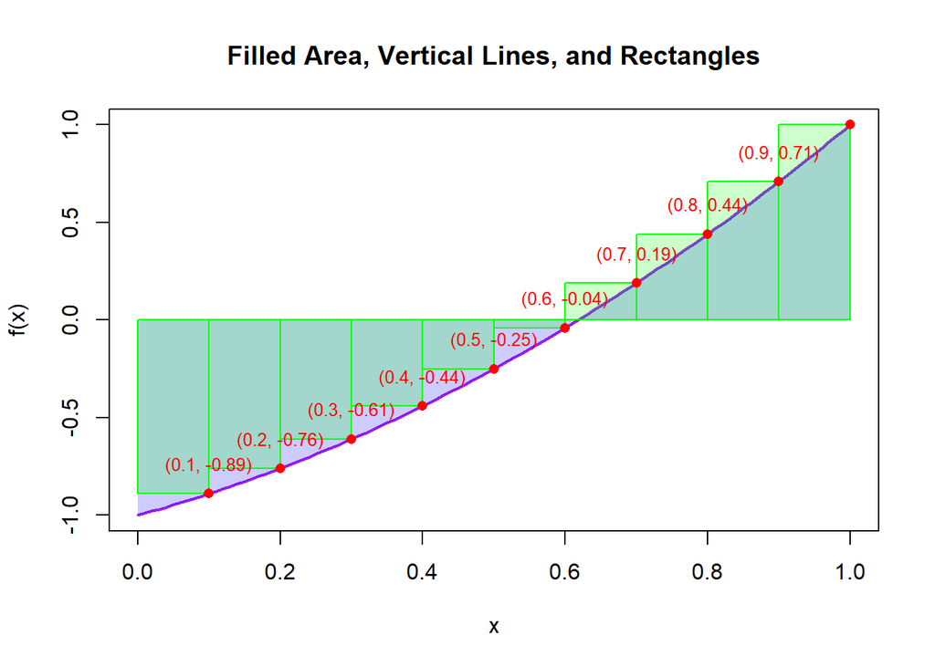

```r
# 定義函數 f(x) = x^2 + x - 1
f <- function(x) {
  x^2 + x - 1
}

# 生成 (0, 1) 區間的右端點（等分為 10 份）
x <- seq(0.1, 1, length.out = 10)

# 計算每個 x 對應的 f(x) 值
f_values <- f(x)

# 繪製 f(x) 的曲線
curve(f(x), from = 0, to = 1, col = "purple", lwd = 2,
      xlab = "x", ylab = "f(x)", main = "Filled Area, Vertical Lines, and Rectangles")

# 使用 polygon 繪製曲線下方到 y=0 的填充區域
x_fine <- seq(0, 1, length.out = 100)
f_fine <- f(x_fine)

polygon(c(x_fine, rev(x_fine)), c(rep(0, length(x_fine)), rev(f_fine)),
        col = rgb(0, 0, 1, 0.2), border = NA)

# 使用 segments 繪製所有垂直線
segments(x, 0, x, f_values, col = "blue", lty = 2)

# 繪製長方形（每個子區間）
rect(x - 0.1, 0, x, f_values, col = rgb(0, 1, 0, 0.2), border = "green")

# 標示右端點的 f(x) 值
points(x, f_values, col = "red", pch = 16)

# 使用 text 標示點的位置
text(x, f_values + 0.05, labels = paste0("(", round(x, 2), ", ", round(f_values, 2), ")"),
     pos = 3, cex = 0.8, col = "red")
```

## 1.47 四群學生,人數 (number) 是 10、20、30、40 人,平均體重 (weight) 分別是 50、55、60、65 公斤,計算全部學生的平均體重。(提示: 將 number 及 weight設定為數字向量。)

```r
# 設定人數和平均體重的數字向量
number <- c(10, 20, 30, 40)
weight <- c(50, 55, 60, 65)

# 計算加權平均體重
total_average_weight <- sum(number * weight) / sum(number)

# 顯示結果
cat("全部學生的平均體重為：", total_average_weight, "公斤\n")
```

```
## 全部學生的平均體重為： 60 公斤
```

## 3.1

畫出 $y = loga (x) x > 0$ 之圖形。

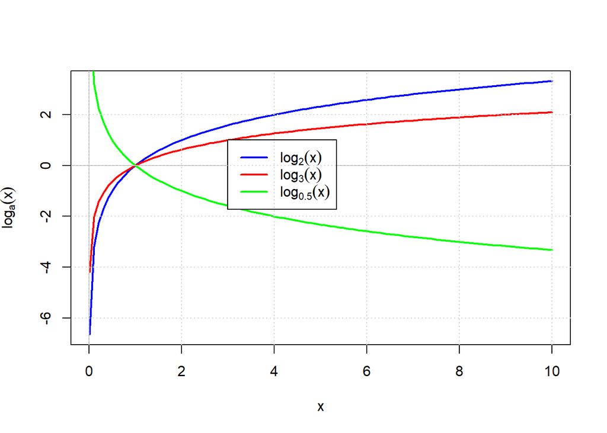

```r
a <- 2  # 可以將 a 設為其他值，如 2, 3, 10 等
b <- 3
c <- 0.5

# 繪製 y = log_a(x) 的圖形
curve(log(x, base = a), from = 0.01, to = 10,
      col = "blue", lwd = 2, ylab = expression(log[a](x)))

# 添加 y = log_b(x) 的曲線
curve(log(x, base = b), from = 0.01, to = 10,
      col = "red", lwd = 2, add = TRUE)

# 添加 y = log_c(x) 的曲線
curve(log(x, base = c), from = 0.01, to = 10,
      col = "green", lwd = 2, add = TRUE)
# 添加水平線和垂直線
abline(h=0,v=0,col="gray")

#添加註解標籤(3,1為圖片上的xy位置)
legend(3,1, legend = c(expression(log[2](x)),
                              expression(log[3](x)),
                              expression(log[0.5](x))),
       col = c("blue", "red", "green"), lty = 1, lwd = 2)
#"topright"：指定圖例位置為右上角。其他可用位置包括"topleft"、"bottomright"、"bottomleft" 等。

# 添加網格線
grid()
```

## 3.2 若有一函數為 $f(x) = sin(kx)/√(k)$,畫出當 k = 2、4、9 時之函數圖形 (需以不同顏色呈現)。

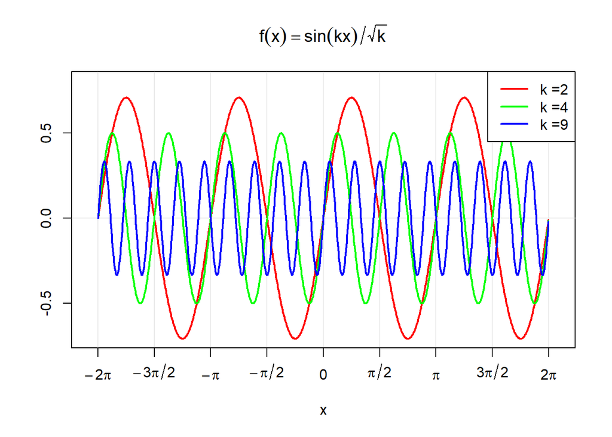

```r
# 定義範圍
xv <- seq(-2*pi, 2*pi, 0.01)

# 繪製空白圖形
plot(0, xlab = "x", ylab = "", xaxt="n",
     main = expression(f(x) == sin(k * x) / sqrt(k)),
     type = "n", xlim = c(-6.5, 6.5), ylim = c(-0.7, 0.8))
abline(h = 0, v = seq(-5/2 * pi, 5/2 * pi, pi/2), col = "#D3D3D380")

# 設置 X 軸標籤
labtxt <- expression(-2 * pi, -3 * pi / 2, -pi, -pi / 2, 0, pi / 2, pi, 3 * pi / 2, 2 * pi)

# 繪製 X 軸
axis(1, labtxt, at = seq(-4/2 * pi, 4/2 * pi, 1/2 * pi))

# 定義 f(x) 函數
f <- function(x, k) {
  sin(k * x) / sqrt(k)
}

# 繪製不同 k 值的 f(x) 圖形
points(xv, f(xv, k = 2), col = "#FF0000", lwd = 2, type = "l")
points(xv, f(xv, k = 4), col = "#00FF00", lwd = 2, type = "l")
points(xv, f(xv, k = 9), col = "#0000FF", lwd = 2, type = "l")

# 添加圖例
legend("topright", legend = paste("k =", c(2, 4, 9), sep = ""),
       lty = 1, lwd = 2, col = c("#FF0000", "#00FF00", "#0000FF"))
```

### 3.3

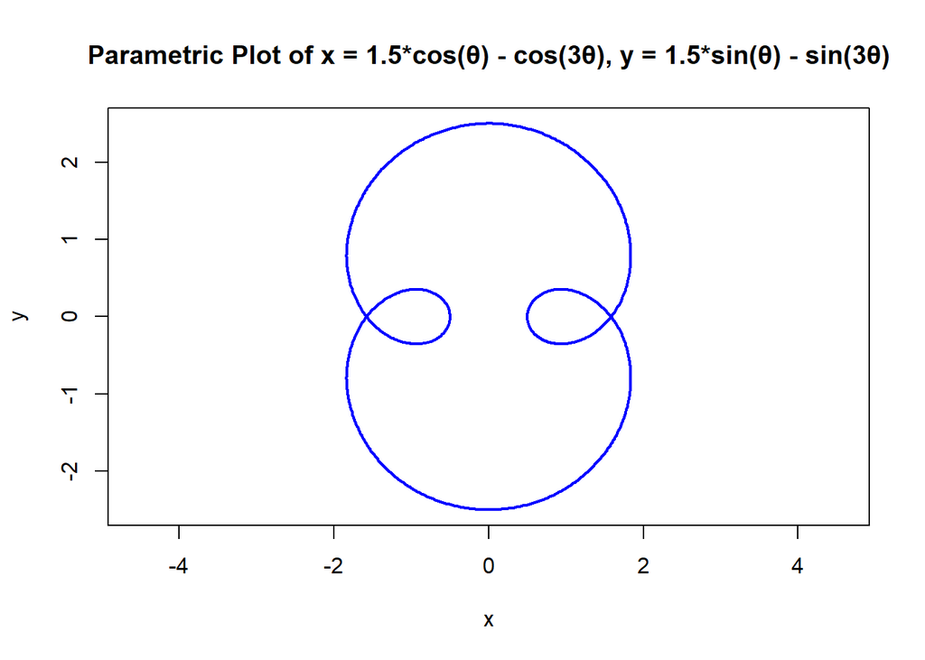

```r
# 定義範圍
theta <- seq(0, 2*pi, length.out = 1000)

# 定義 x 和 y
x <- 1.5 * cos(theta) - cos(3 * theta)
y <- 1.5 * sin(theta) - sin(3 * theta)

# 繪製圖形
plot(x, y, type = "l", col = "blue", lwd = 2,
     main = "Parametric Plot of x = 1.5*cos(θ) - cos(3θ), y = 1.5*sin(θ) - sin(3θ)",
     xlab = "x", ylab = "y", asp = 1)
```

### 3.36

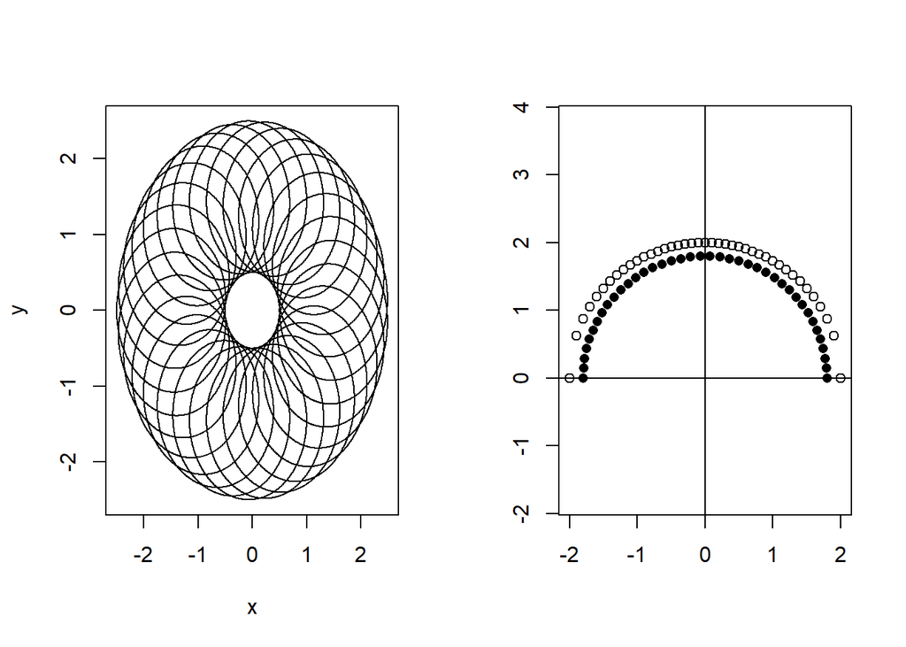

```r
# 設置繪圖窗口，分成 1 行 2 列
par(mfrow = c(1, 2))

# 定義範圍
theta <- seq(0, 2*pi, length.out = 20000)

# 計算參數方程
xv <- 1.5 * cos(theta) - cos(30 * theta)
yv <- 1.5 * sin(theta) - sin(30 * theta)

# 繪製第一個圖形
plot(xv, yv, type = "l", xlab = "x", ylab = "y")

# 定義第二個圖形的範圍
r1 <- 2
xv <- seq(-2, 2, 0.1)
yv <- sqrt(r1^2 - xv^2)

# 繪製第二個圖形
plot(xv, yv, asp = 1, xlab = "", ylab = "")
abline(v = 0, h = 0)

# 添加另一個圓的點
r2 <- 1.8
thv <- seq(0, pi, length.out = 40)
points(r2 * cos(thv), r2 * sin(thv), pch = 16)
```

$$\left\{
\begin{aligned}
x &= r \cos \theta \\
y &= r \sin \theta
\end{aligned}
\right\}
\quad \Leftrightarrow \quad
\left\{
\begin{aligned}
\theta &= \arctan \frac{y}{x} \\
r &= \sqrt{x^2 + y^2}
\end{aligned}
\right\}$$

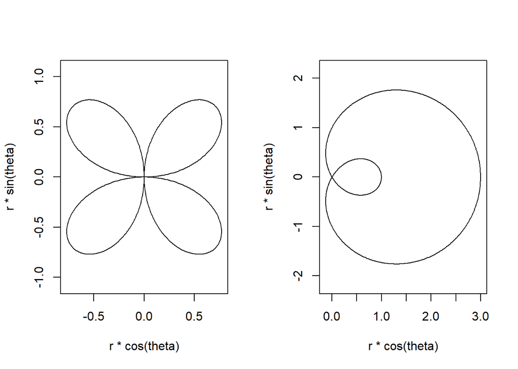

```r
# 設置繪圖窗口，分成 1 行 2 列
par(mfrow = c(1, 2))

# 定義範圍
theta <- seq(0, 2*pi, length.out = 1000)

# 四葉曲線 (Rose curve)
r <- sin(2 * theta)
plot(r * cos(theta), r * sin(theta), asp = 1, type = "l",
     xlab = "r * cos(theta)", ylab = "r * sin(theta)")

# 螺旋曲線 (Spiral)
r <- 2 * cos(theta) + 1
plot(r * cos(theta), r * sin(theta), asp = 1, type = "l",
     xlab = "r * cos(theta)", ylab = "r * sin(theta)")
```

Four-leaved rose (四瓣玫瑰線)：$r = \sin 2\theta$. Limacon (帕斯卡蝸線)：$r = 2 \cos \theta + 1$. Cardioid (心臟線)：$r = 1 - \sin \theta$.

Lemniscate (雙紐線)：$r^2 = \cos 2\theta$.

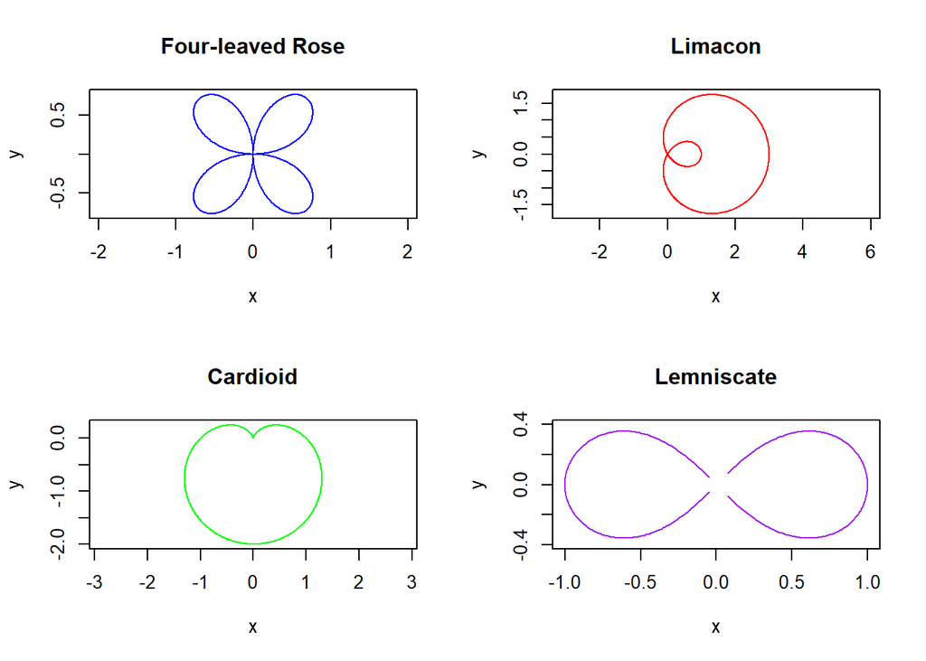

```r
# 設置繪圖窗口，分成 2 行 2 列
par(mfrow = c(2, 2))

# 定義範圍
theta <- seq(0, 2*pi, length.out = 1000)

# 1. Four-leaved rose (四瓣玫瑰線): r = sin(2 * theta)
r <- sin(2 * theta)
plot(r * cos(theta), r * sin(theta), type = "l", col = "blue",
     xlab = "x", ylab = "y", main = "Four-leaved Rose", asp = 1)

# 2. Limacon (帕斯卡蝸線): r = 2 * cos(theta) + 1
r <- 2 * cos(theta) + 1
plot(r * cos(theta), r * sin(theta), type = "l", col = "red",
     xlab = "x", ylab = "y", main = "Limacon", asp = 1)

# 3. Cardioid (心臟線): r = 1 - sin(theta)
r <- 1 - sin(theta)
plot(r * cos(theta), r * sin(theta), type = "l", col = "green",
     xlab = "x", ylab = "y", main = "Cardioid", asp = 1)

# 4. Lemniscate (雙紐線): r^2 = cos(2 * theta)
r <- sqrt(cos(2 * theta))
plot(r * cos(theta), r * sin(theta), type = "l", col = "purple",
     xlab = "x", ylab = "y", main = "Lemniscate", asp = 1)
```

## 3.6 畫出 sin 及 cos 函數如下圖。(提示: curve, abline, expression, text)

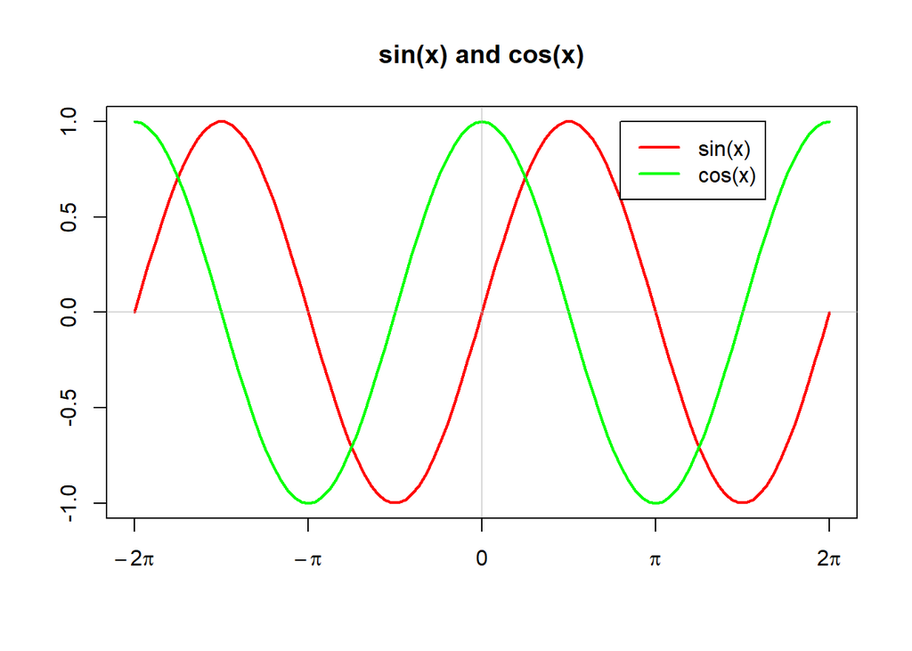

```r
# 設置繪圖範圍
# 繪製 sin(x) 函數
curve(sin(x), -2*pi, 2*pi, lwd = 2, col = "red", xlab = "", ylab = "", xaxt = "n")

# 繪製 cos(x) 函數
curve(cos(x), lwd = 2, col = "green", add = TRUE)

# 添加水平和垂直輔助線
abline(h = 0, v = 0, col = "#b0b0b080")

# 設置 X 軸標籤
labtxt <- expression(-2 * pi, -pi, 0, pi, 2 * pi)
axis(1, labels = labtxt, at = seq(-2 * pi, 2 * pi, pi))

# 添加圖例
legend(2.5, 1, legend = c("sin(x)", "cos(x)"), col = c("red", "green"), lty = 1, lwd = 2)

# 添加標題
title("sin(x) and cos(x)")
```

## 3.7 畫出 tan 函數如下圖。(提示 1: plot, curve, axis) (提示 2: points.at <- c(-2*pi, -3*pi/2, -pi/2, pi/2, 3*pi/2, 2*pi))

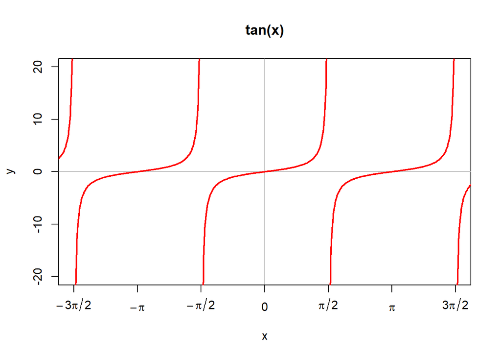

```r
# 繪製空白圖形框架
plot(0, xlim = c(-3*pi/2, 3*pi/2), ylim = c(-20, 20), type = "n",
     xlab = "x", ylab = "y", xaxt = "n", main = "tan(x)")

# 添加水平和垂直輔助線
abline(h = 0, v = 0, col = "gray")

# 設置 X 軸標籤
labeltxt <- c(expression(-3*pi/2), expression(-pi), expression(-pi/2),
              0, expression(pi/2), expression(pi), expression(3*pi/2))
axis(1, labels = labeltxt, at = seq(-3*pi/2, 3*pi/2, pi/2))

# 繪製 tan(x) 函數，分段繪製以避免無限值
curve(tan(x), -2*pi + 0.0001, -3*pi/2 - 0.0001, add = TRUE, col = "red", lwd = 2)  # 新增
curve(tan(x), -3*pi/2 + 0.0001, -pi - 0.0001, add = TRUE, col = "red", lwd = 2)
curve(tan(x), -pi + 0.0001, -pi/2 - 0.0001, add = TRUE, col = "red", lwd = 2)
curve(tan(x), -pi/2 + 0.0001, pi/2 - 0.0001, add = TRUE, col = "red", lwd = 2)
curve(tan(x), pi/2 + 0.0001, pi - 0.0001, add = TRUE, col = "red", lwd = 2)
curve(tan(x), pi + 0.0001, 3*pi/2 - 0.0001, add = TRUE, col = "red", lwd = 2)
curve(tan(x), 3*pi/2 + 0.0001, 2*pi - 0.0001, add = TRUE, col = "red", lwd = 2)  # 新增
```

## 3.10 下圖紅色曲線為標準常態機率密度函數 (dnorm),請畫出下圖。(限用兩次 arrows, 一次 text,一次 abline,詳見提示。)

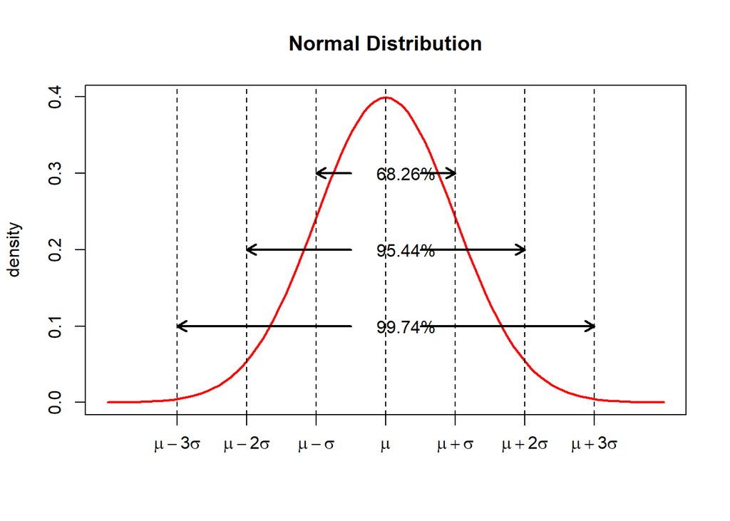

```r
# 繪製標準正態分佈曲線
curve(dnorm(x), -4, 4, col = "red", xaxt = "n", xlab = "",
      ylab = "density", main = "Normal Distribution", lwd = 2)

# 添加垂直輔助線
abline(v = c(-3, -2, -1, 0, 1, 2, 3), lty = 2)

# 添加文字標註
text(rep(0.3, 3), seq(0.3, 0.1, -0.1), c("68.26%", "95.44%", "99.74%"))

# 設置 X 軸標籤
labeltxt <- c(expression(mu - 3 * sigma), expression(mu - 2 * sigma),
              expression(mu - sigma), expression(mu),
              expression(mu + sigma), expression(mu + 2 * sigma),
              expression(mu + 3 * sigma))
axis(1, at = seq(-3, 3, 1), labels = labeltxt)

# 添加箭頭
ix <- rep(0.5, 3)
iy <- seq(0.1, 0.3, 0.1)
ex <- seq(3, 1)
ey <- iy

arrows(ix, iy, ex, ey, lwd = 2, length = 0.1, angle = 30)
arrows(-ix, iy, -ex, ey, lwd = 2, length = 0.1, angle = 30)
```

## 3.11

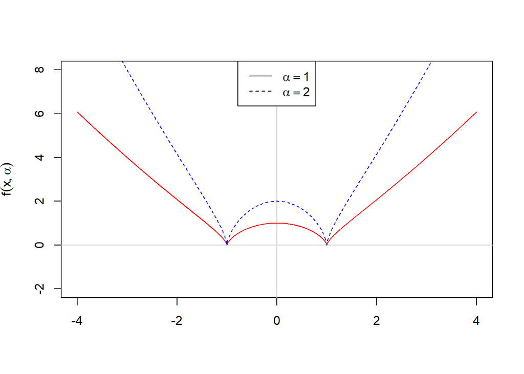

```r
# 定義函數 f(x, alpha)
f <- function(x, alpha) {
  alpha * ((x^2 - 1)^2)^(1/3)
}

# 繪製空白圖形框架
plot(0, type = "n", xlim = c(-4, 4), ylim = c(-2, 8),
     xlab = "", ylab = expression(f(x, alpha)))

# 添加輔助線
abline(v = 0, h = 0, col = "#D3D3D3")

# 定義 x 範圍
xv <- seq(-4, 4, 0.005)

# 繪製不同 alpha 值的 f(x) 曲線
points(xv, f(xv, alpha = 1), type = "l", lty = 1, col="red")
points(xv, f(xv, alpha = 2), type = "l", lty = 2, col="blue")


# 添加圖例
legtxt <- expression(alpha == 1, alpha == 2)
legend("top", legend = legtxt, lty = 1:3,cex = 1)
```

## 3.15

$f(x; \sigma) = \frac{x}{\sigma^2} e^{-\frac{x^2}{2\sigma^2}}, \quad x \geq 0$

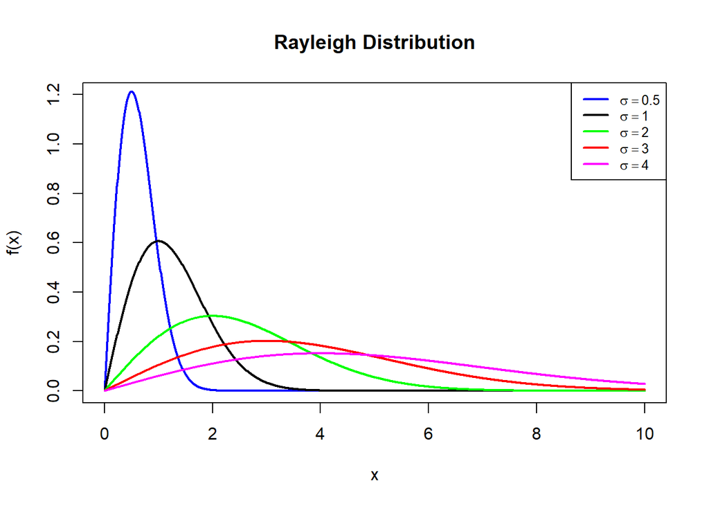

```r
# 定義 Rayleigh 分佈的概率密度函數
rayleigh_pdf <- function(x, sigma) {
  (x / sigma^2) * exp(-x^2 / (2 * sigma^2))
}

# 設置 x 範圍
x <- seq(0, 10, length.out = 1000)

# 繪製不同 sigma 值的 PDF 曲線
plot(x, rayleigh_pdf(x, sigma = 0.5), type = "l", col = "blue", lwd = 2,
     xlab = "x", ylab = "f(x)", main = "Rayleigh Distribution", ylim = c(0, 1.2))

# 添加不同 sigma 值的曲線
lines(x, rayleigh_pdf(x, sigma = 1.0), col = "black", lwd = 2)
lines(x, rayleigh_pdf(x, sigma = 2.0), col = "green", lwd = 2)
lines(x, rayleigh_pdf(x, sigma = 3.0), col = "red", lwd = 2)
lines(x, rayleigh_pdf(x, sigma = 4.0), col = "magenta", lwd = 2)

# 添加圖例
legend("topright", legend = c(expression(sigma == 0.5), expression(sigma == 1.0),
                              expression(sigma == 2.0), expression(sigma == 3.0),
                              expression(sigma == 4.0)),
       col = c("blue", "black", "green", "red", "magenta"), lwd = 2,  cex = 0.8)
```

## 3.18

對數常態分佈（Log-Normal Distribution）的概率密度函數，其數學公式為：

$f(x; \mu, \sigma) = \frac{1}{x \sqrt{2\pi\sigma^2}} \exp \left( -\frac{(\ln x - \mu)^2}{2\sigma^2} \right), \quad x > 0, \, \mu \in \mathbb{R}, \, \sigma > 0$

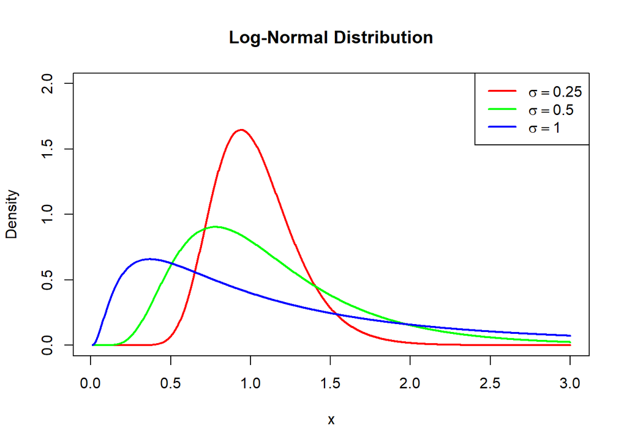

```r
# 定義 Log-Normal 分佈的 PDF 函數
lognorm_pdf <- function(x, mu = 0, sigma = 1) {
  (1 / (x * sqrt(2 * pi * sigma^2))) *
    exp(-((log(x) - mu)^2) / (2 * sigma^2))
}

# 設置 x 範圍
x <- seq(0.01, 3, length.out = 1000)

# 繪製不同 sigma 值的 PDF 曲線
plot(x, lognorm_pdf(x, mu = 0, sigma = 0.25), type = "l", col = "red", lwd = 2,
     xlab = "x", ylab = "Density", main = "Log-Normal Distribution", ylim = c(0, 2))

# 添加不同 sigma 值的曲線
lines(x, lognorm_pdf(x, mu = 0, sigma = 0.5), col = "green", lwd = 2)
lines(x, lognorm_pdf(x, mu = 0, sigma = 1), col = "blue", lwd = 2)

# 添加圖例
legend("topright", legend = c(expression(sigma == 0.25), expression(sigma == 0.5), expression(sigma == 1)),
       col = c("red", "green", "blue"), lwd = 2)
```

## 3.20

```r
# 定義函數 f(x) 和 f'(x)
f <- function(x) 12 * x^5 - 20 * x^3 + 7
f_prime <- function(x) 60 * x^4 - 60 * x^2

# 使用牛頓法尋找方程的根，加入 NA 檢查
newton_method <- function(f, f_prime, x0, tol = 1e-7, max_iter = 100) {
  x <- x0
  for (i in 1:max_iter) {
    f_prime_x <- f_prime(x)
    if (is.na(f_prime_x) || f_prime_x == 0) {
      return(NA)  # 如果導數為 NA 或 0，返回 NA
    }
    x_new <- x - f(x) / f_prime_x
    if (is.na(x_new) || abs(x_new - x) < tol) {
      return(x_new)
    }
    x <- x_new
  }
  return(NA)  # 未收斂
}

# 設置初始值並求解
initial_guesses <- seq(-2, 2, by = 0.5)
roots <- sapply(initial_guesses, function(x0) newton_method(f, f_prime, x0))
unique_roots <- unique(round(roots, 5))  # 去重並取前5位小數

cat("Roots found using Newton's Method:", unique_roots, "\n")
```

```
## Roots found using Newton's Method: -1.37513 NA 1.11738 0.85351
```

```r
# 設置區間和分割數
a <- -1
b <- 0.5
n <- 5
dx <- (b - a) / n
x_vals <- seq(a, b, length.out = n + 1)
y_vals <- f(x_vals)

# 計算黎曼上和和下和
upper_sum <- sum(pmax(y_vals[-1], y_vals[-length(y_vals)]) * dx)
lower_sum <- sum(pmin(y_vals[-1], y_vals[-length(y_vals)]) * dx)
midpoint_sum <- sum(f(seq(a + dx/2, b - dx/2, length.out = n)) * dx)

# 使用 integrate() 函數計算定積分
integral_result <- integrate(f, a, b)

# 輸出黎曼和和積分結果
cat("Upper Riemann Sum:", upper_sum, "\n")
```

```
## Upper Riemann Sum: 14.6592
```

```r
cat("Lower Riemann Sum:", lower_sum, "\n")
```

```
## Lower Riemann Sum: 11.6217
```

```r
cat("Midpoint Riemann Sum:", midpoint_sum, "\n")
```

```
## Midpoint Riemann Sum: 13.25562
```

```r
cat("Integral from", a, "to", b, ":", integral_result$value, "\n")
```

```
## Integral from -1 to 0.5 : 13.21875
```

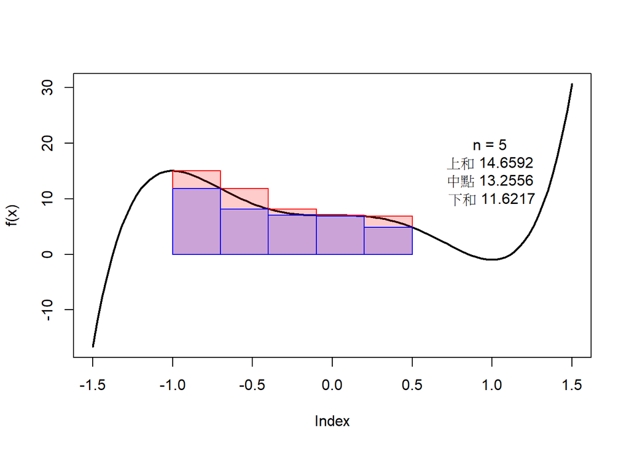

```r
# 繪製函數曲線和黎曼和
curve(f(x), from = -1.5, to = 1.5, col = "black", lwd = 2,
      xlab = "Index", ylab = "f(x)")

# 添加黎曼上和和下和的矩形
rect(x_vals[-1], 0, x_vals[-length(x_vals)], pmax(y_vals[-1], y_vals[-length(y_vals)]),
     border = "red", col = rgb(1, 0, 0, 0.2))
rect(x_vals[-1], 0, x_vals[-length(x_vals)], pmin(y_vals[-1], y_vals[-length(y_vals)]),
     border = "blue", col = rgb(0, 0, 1, 0.2))

# 添加文本說明
text(1, 15, labels = paste("n =", n,
                           "\n上和", round(upper_sum, 4),
                           "\n中點", round(midpoint_sum, 4),
                           "\n下和", round(lower_sum, 4)))
```

## 3.32

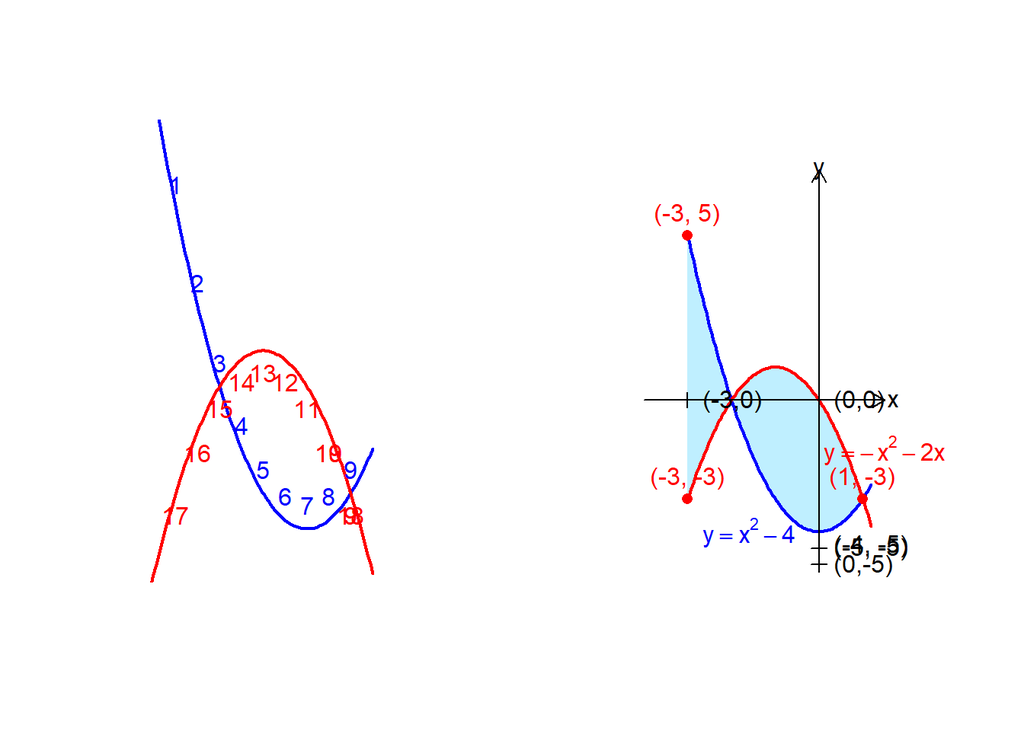

```r
# 設置繪圖窗口，分成 1 行 2 列
par(mfrow = c(1, 2))

# 定義函數 f1(x) 和 f2(x)
f1 <- function(x) x^2 - 4
f2 <- function(x) -x^2 - 2*x

# 第一個圖
plot(0, xlim = c(-4, 3), ylim = c(-5, 7), type = "n", xlab = "", ylab = "", axes = FALSE)
curve(f1(x), -4, 1.5, add = TRUE, col = "blue", lwd = 2)
curve(f2(x), -4, 1.5, add = TRUE, col = "red", lwd = 2)

# 設置 x 值範圍
xv <- seq(-3, 1, 0.5)

# 在函數上添加標注
text(xv, f1(xv), labels = 1:length(xv), pos = 3, col = "blue")
text(rev(xv), f2(rev(xv)), labels = length(xv):(2 * length(xv) + 1), pos = 1, col = "red")

# 第二個圖
plot(0, xlim = c(-4, 3), ylim = c(-5, 8), type = "n", xlab = "", ylab = "", axes = FALSE)
xv <- seq(-3, 1, 0.05)

# 填充區域
polygon(c(xv, rev(xv)), c(f1(xv), f2(rev(xv))), col = "lightblue1", border = NA)

# 繪製兩個函數的曲線
curve(f1(x), -3, 1.2, add = TRUE, col = "blue", lwd = 2)
curve(f2(x), -3, 1.2, add = TRUE, col = "red", lwd = 2)

# 添加箭頭
arrows(-4, 0, 1.5, 0, length = 0.1, col = "black")
arrows(0, -5, 0, 7, length = 0.1, col = "black")

# 添加函數標籤
ers1 <- expression(y == x^2 - 4)
ers2 <- expression(y == -x^2 - 2*x)
text(-2 + 0.4, -4, ers1, col = "blue")
text(1.5, -1.5, ers2, col = "red")

# 添加坐標標注
text(c(1.7, 0), c(0, 7), c("x", "y"))

# 添加紅色的交點
points(c(-3, -3, 1), c(5, -3, -3), pch = 16, col = "red")
text(c(-3, -3, 1), c(5, -3, -3), labels = c("(-3, 5)", "(-3, -3)", "(1, -3)"), pos = 3, col = "red")

# 添加其他點
other_x <- c(-3, 0, 0)
other_y <- c(0, 0, -5)
points(other_x, other_y, pch = 3, col = "black")
text(other_x, other_y, labels = paste("(", other_x, ",", other_y, ")", sep = ""), pos = 4)

# 添加下方的點
points(c(0, 0), c(-4.5, -5), pch = 3, col = "black")
text(c(0, 0), c(-4.4, -4.5), labels = c("(-4, -5)", "(-5, -5)"), pos = 4)
```

##3.32(b)

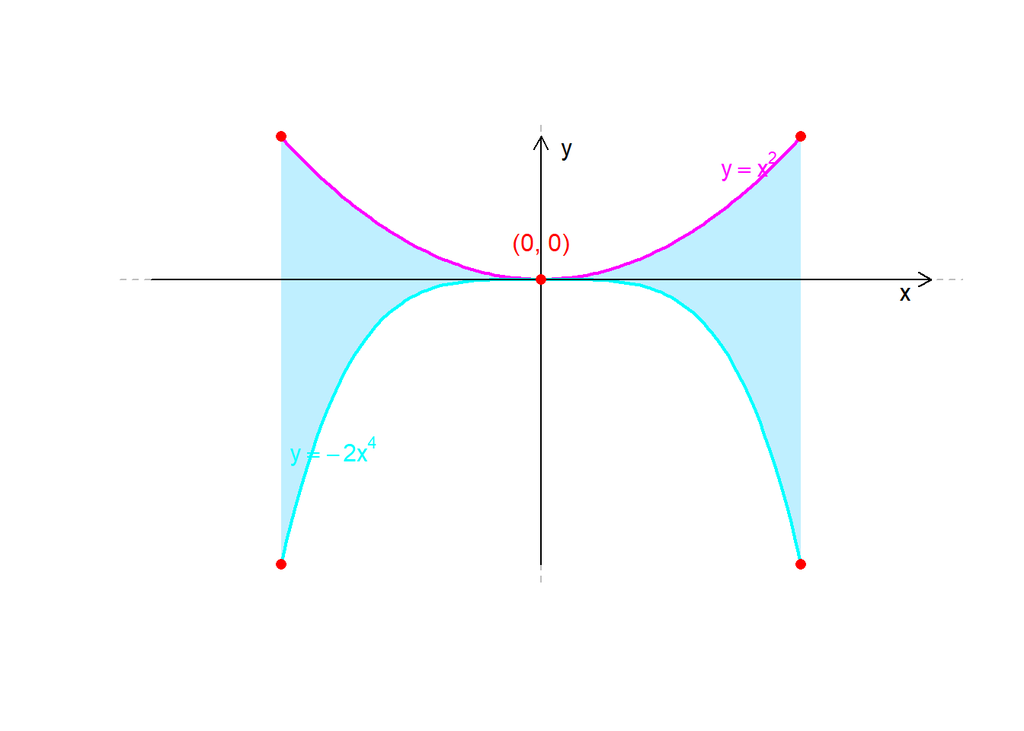

```r
# 設置繪圖窗口
par(mfrow = c(1, 1))

# 定義函數 f1(x) 和 f2(x)
f1 <- function(x) x^2
f2 <- function(x) -2 * x^4

# 繪製圖形
plot(0, xlim = c(-1.5, 1.5), ylim = c(-2, 1), type = "n", xlab = "", ylab = "", axes = FALSE)

# 設置 x 值範圍
xv <- seq(-1, 1, length.out = 100)

# 填充區域
polygon(c(xv, rev(xv)), c(f1(xv), f2(rev(xv))), col = "lightblue1", border = NA)

# 繪製兩個函數的曲線
curve(f1(x), from = -1, to = 1, col = "magenta", lwd = 2, add = TRUE)
curve(f2(x), from = -1, to = 1, col = "cyan", lwd = 2, add = TRUE)

# 添加 X 和 Y 軸線
abline(h = 0, v = 0, col = "gray", lwd = 1, lty = 2)

# 添加箭頭
arrows(-1.5, 0, 1.5, 0, length = 0.1, col = "black")  # X 軸
arrows(0, -2, 0, 1, length = 0.1, col = "black")  # Y 軸

# 添加函數標籤
text(0.8, 0.8, expression(y == x^2), col = "magenta")
text(-0.8, -1.2, expression(y == -2 * x^4), col = "cyan")

# 標記極值點
points(0, 0, pch = 16, col = "red")  # 極值點 (0, 0)
text(0, 0.1, "(0, 0)", pos = 3, col = "red")

points(-1, f1(-1), pch = 16, col = "red")  # 極值點 (-1, 1)
text(-1, f1(-1) + 0.1, "(-1, 1)", pos = 3, col = "red")

points(1, f1(1), pch = 16, col = "red")  # 極值點 (1, 1)
text(1, f1(1) + 0.1, "(1, 1)", pos = 3, col = "red")

points(-1, f2(-1), pch = 16, col = "red")  # 極值點 (-1, -2)
text(-1, f2(-1) - 0.1, "(-1, -2)", pos = 1, col = "red")

points(1, f2(1), pch = 16, col = "red")  # 極值點 (1, -2)
text(1, f2(1) - 0.1, "(1, -2)", pos = 1, col = "red")

# 添加坐標標注
text(1.4, -0.1, "x", col = "black")
text(0.1, 0.9, "y", col = "black")
```

## 3.33

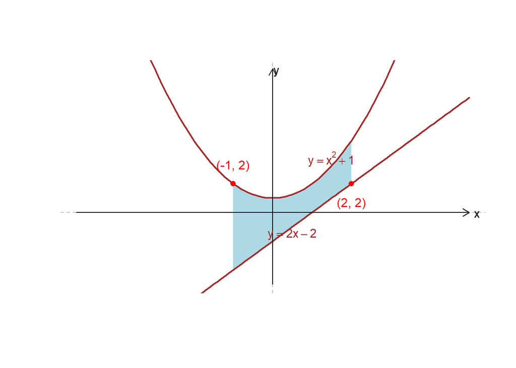

```r
# 設置繪圖窗口
par(mfrow = c(1, 1))

# 定義兩個函數
f1 <- function(x) x^2 + 1
f2 <- function(x) 2*x - 2

# 繪製空白圖形
plot(0, xlim = c(-5, 5), ylim = c(-5, 10), type = "n", xlab = "", ylab = "", axes = FALSE)

# 設置 x 值範圍
xv <- seq(-1, 2, length.out = 100)

# 填充兩條曲線之間的區域
polygon(c(xv, rev(xv)), c(f1(xv), f2(rev(xv))), col = "lightblue", border = NA)

# 繪製兩條曲線
curve(f1(x), from = -5, to = 5, col = "brown", lwd = 2, add = TRUE)
curve(f2(x), from = -5, to = 5, col = "brown", lwd = 2, add = TRUE)

# 添加 X 和 Y 軸
abline(h = 0, v = 0, col = "gray", lwd = 1, lty = 2)

# 添加交點標注
points(-1, f1(-1), pch = 16, col = "red")
text(-1, f1(-1) + 0.5, "(-1, 2)", pos = 3, col = "red")
points(2, f2(2), pch = 16, col = "red")
text(2, f2(2) - 0.5, "(2, 2)", pos = 1, col = "red")

# 添加箭頭
arrows(-5, 0, 5, 0, length = 0.1, col = "black")  # X 軸
arrows(0, -5, 0, 10, length = 0.1, col = "black")  # Y 軸

# 添加函數標籤
text(1.5, f1(1.5) + 0.5, expression(y == x^2 + 1), col = "brown")
text(0.5, f2(0.5) - 0.5, expression(y == 2 * x - 2), col = "brown")

# 添加坐標標注
text(5.2, -0.1, "x", col = "black")
text(0.1, 9.8, "y", col = "black")
```